# Flight Route

Chun Su

10/7/2019

# Data

Data used in this pratice problem is download from https://openflights.org/

- airports: https://raw.githubusercontent.com/jpatokal/openflights/master/data/airports.dat
- routes: https://raw.githubusercontent.com/jpatokal/openflights/master/data/routes.dat
- airlines: https://raw.githubusercontent.com/jpatokal/openflights/master/data/airlines.dat

```r
library(tidyverse)
library(igraph)
library(ggraph)
```

```r
airports = read_csv(
        "https://raw.githubusercontent.com/jpatokal/openflights/master/data/airports.dat",
        col_names = c("airport_id","name","city","country","IATA","ICAO","latitude","longitude","altitude","timezone","dst","tz_db","type","source"),
        col_types = cols(timezone = col_character()),
        na = c("", "\\N")
)

routes = read_csv(
        "https://raw.githubusercontent.com/jpatokal/openflights/master/data/routes.dat",
        col_names = c("airline","airline_id","source_airport","source_airport_id","dest_airport","dest_airport_id","codeshare","stops","equipment") ,
        na = c("", "\\N")
)

airlines = read_csv(
        "https://raw.githubusercontent.com/jpatokal/openflights/master/data/airlines.dat",
        col_names = c("airline_id","airline_name","alias","IATA","ICAO","callsign","country","active"),
        na = c("", "\\N")
        )
```

# Data clean (optional)

Clean out the data. This part is optional. The exercise can start by using clean data `flight.Rdata`.

```r
# clean routes (fill the airport_id which is NA using airports)
routes = routes %>%
        select(source_airport_id, dest_airport_id, source_airport, dest_airport, airline, airline_id, stops)

fetch_airport_id <- function(airport_name) {
        if(nchar(airport_name) == 3){
                id = airports %>% filter(IATA==get("airport_name")) %>% select(airport_id) %>% .$airport_id
        }else if (nchar(airport_name)==4){
                id = airports %>% filter(ICAO==get("airport_name")) %>% select(airport_id) %>% .$airport_id
        }
        # if(length(id)==1){
        #         id
        # }else{
        #         NA
        # }
        if (length(id)==1){
                id
        }else{
                NA
        }
}

routes = bind_rows(
        routes %>%
        filter(!is.na(dest_airport_id), !is.na(source_airport_id)),
        routes %>%
        filter(is.na(dest_airport_id) | is.na(source_airport_id)) %>%
        mutate(dest_airport_id=if_else(is.na(dest_airport_id), sapply(dest_airport, fetch_airport_id ), dest_airport_id)) %>%
        mutate(source_airport_id=if_else(is.na(source_airport_id), sapply(source_airport, fetch_airport_id ), source_airport_id))
)

fetch_airline_id <- function(airline){
        if(nchar(airline)==2){
                id =  airlines %>% filter(IATA==airline) %>% select(airline_id) %>% .$airline_id
        } else if(nchar(airline)==3) {
                id = airlines %>% filter(ICAO==airline) %>% select(airline_id) %>% .$airline_id
        }
        if (length(id)==1){
                id
        }else{
                NA
        }
}

routes = bind_rows(
        routes %>% filter(!is.na(airline_id)),
        routes %>% filter(is.na(airline_id)) %>%
        mutate(airline_id = ifelse(is.na(airline_id), sapply(airline, fetch_airline_id), airline_id))
)

routes = routes %>% na.omit

# find conflicted information (airport_id and airport should be one-to-one pairing)
routes_airports = bind_rows(
        routes %>% select(airport=source_airport, airport_id= source_airport_id),
        routes %>% select(airport=dest_airport, airport_id= dest_airport_id)
) %>% distinct()


semi_join(
        routes_airports,
        routes_airports %>%
        group_by(airport) %>%
        summarise(n_id=n_distinct(airport_id)) %>%
        ungroup() %>% filter(n_id > 1)
)
```

```
## # A tibble: 0 x 2
## # … with 2 variables: airport <chr>, airport_id <dbl>
```

```r
conflicts = semi_join(
        routes_airports,
        routes_airports %>%
                group_by(airport_id) %>%
                summarise(n_id=n_distinct(airport)) %>%
                ungroup() %>% filter(n_id > 1)
)
conflicts
```

```
## # A tibble: 2 x 2
##   airport airport_id
##   <chr>        <dbl>
## 1 SIC           6783
## 2 NOP           6783
```

```r
conflicts = anti_join(
        conflicts,
        airports %>% dplyr::rename(airport=IATA)
) %>% select(airport_id,airport)
conflicts
```

```
## # A tibble: 1 x 2
##   airport_id airport
##        <dbl> <chr>
## 1       6783 SIC
```

```r
routes = routes %>%
        mutate(source_airport = ifelse(source_airport=="SIC","NOP",source_airport)) %>%
        mutate(dest_airport = ifelse(dest_airport=="SIC","NOP",dest_airport))

routes_airports = bind_rows(
        routes %>% select(airport=source_airport, airport_id= source_airport_id),
        routes %>% select(airport=dest_airport, airport_id= dest_airport_id)
) %>% distinct()


# airline clean up
route_airlines = routes %>% select(airline, airline_id) %>% distinct()

route_airlines %>% group_by(airline) %>%
        summarise(n_id=n_distinct(airline_id)) %>%
        ungroup() %>% filter(n_id > 1)
```

```
## # A tibble: 0 x 2
## # … with 2 variables: airline <chr>, n_id <int>
```

```r
route_airlines %>% group_by(airline_id) %>%
        summarise(n_id=n_distinct(airline)) %>%
        ungroup() %>% filter(n_id > 1)
```

```
## # A tibble: 0 x 2
## # … with 2 variables: airline_id <dbl>, n_id <int>
```

```r
# add other airports attributes
routes_airports = left_join(
        routes_airports,
        airports %>% select(airport_id, name, city, country, latitude, longitude, timezone)
)
# add other airlines attributes
route_airlines = left_join(
        route_airlines,
        airlines %>% select(airline_id, airline_name, country, active)
)
save(routes, route_airlines, routes_airports, file = "flights.Rdata")
```

# build igraph from edge and vertex data.frame

In this practice, we will use routes as edge and airports as vertices.

```r
load("flights.Rdata")

# build routes_g
routes_g = igraph::graph_from_data_frame(
        routes %>% select(from=source_airport, to=dest_airport, airline, stops),
        directed = T,
        vertices = routes_airports %>%
                dplyr::rename(name=airport, fullname=name) %>%
                select(name, fullname, country, city, latitude, longitude, timezone)
)
```

# Exercise 1

How many different ways with least stops to travel from Philadelphia in US `(city=="Philadelphia", country=="United States")` to Beijing in China `(city=="Beijing", country=="China")`?

Hints: `all_shortest_paths()` to find possible tranfer paths, then get all possible airlines

```r
# get the airport_id for the departure and destination
depart =  routes_airports %>%
        filter(city=="Philadelphia", country=="United States") %>%
        pull(airport)
depart
```

```
## [1] "PHL"
```

```r
dest =  routes_airports %>%
        filter(city=="Beijing", country=="China") %>%
        pull(airport)
dest
```

```
## [1] "PEK" "NAY"
```

```r
# shortest paths from depart to dest
possible_paths = all_shortest_paths(routes_g,from=depart, to=dest, mode="out")$res

possible_paths = unique(lapply(possible_paths, function(x){x %>% igraph::as_ids()}))

min_distance = min(sapply(possible_paths, length))

shortest_paths = possible_paths[sapply(possible_paths, function(x){length(x)==min_distance})]
# extract airline info for each shortest path

# extract_airlineInf <- function(short_path){
#         n = length(short_path)
#         # create edge ids
#         eids = character(n-1)
#         for (i in 1:n-1) {
#                 eids[i]=paste(short_path[i],short_path[i+1],sep="|")
#         }
#         # subgraph using edge ids
#         sub_g = subgraph.edges(routes_g, eids, delete.vertices = TRUE)
#
#         # return data.frame for airline information
#         igraph::as_data_frame(sub_g, what="edges")
# }

extract_airlineInf2 <- function(short_path){
        path_orders=1:length(short_path)

        names(path_orders) = short_path

        # subgraph using vertex ids
        sub_g2 = induced_subgraph(routes_g, short_path)

        # return data.frame for airline information
        igraph::as_data_frame(sub_g2, what="edges") %>% tbl_df() %>%
                filter(path_orders[from] < path_orders[to])
}

shortest_path_airlines = lapply(shortest_paths, extract_airlineInf2)

names(shortest_path_airlines) = sapply(shortest_paths, function(x){paste(x,collapse="->")})

shortest_path_airlines
```

```
## $`PHL->SFO->PEK`
## # A tibble: 7 x 4
##   from  to    airline stops
##   <chr> <chr> <chr>   <dbl>
## 1 PHL   SFO   VX          0
## 2 PHL   SFO   US          0
## 3 PHL   SFO   UA          0
## 4 PHL   SFO   AA          0
## 5 SFO   PEK   US          0
## 6 SFO   PEK   UA          0
## 7 SFO   PEK   CA          0
##
## $`PHL->SEA->PEK`
## # A tibble: 8 x 4
##   from  to    airline stops
##   <chr> <chr> <chr>   <dbl>
## 1 PHL   SEA   US          0
## 2 PHL   SEA   AS          0
## 3 PHL   SEA   AA          0
## 4 SEA   PEK   MU          0
## 5 SEA   PEK   HU          0
## 6 SEA   PEK   DL          0
## 7 SEA   PEK   CZ          0
## 8 SEA   PEK   AA          0
##
## $`PHL->IAH->PEK`
## # A tibble: 5 x 4
##   from  to    airline stops
##   <chr> <chr> <chr>   <dbl>
## 1 PHL   IAH   US          0
## 2 PHL   IAH   UA          0
## 3 PHL   IAH   AA          0
## 4 IAH   PEK   UA          0
## 5 IAH   PEK   CA          0
##
## $`PHL->IAD->PEK`
## # A tibble: 3 x 4
##   from  to    airline stops
##   <chr> <chr> <chr>   <dbl>
## 1 PHL   IAD   UA          0
```

[output cut: 157 more lines]

```
## 2 ORD   PEK   UA          0
## 3 ORD   PEK   HU          0
## 4 ORD   PEK   CA          0
## 5 ORD   PEK   AA          0
## 6 PHL   ORD   US          0
## 7 PHL   ORD   UA          0
## 8 PHL   ORD   AA          0
##
## $`PHL->ZRH->PEK`
## # A tibble: 3 x 4
##   from  to    airline stops
##   <chr> <chr> <chr>   <dbl>
## 1 ZRH   PEK   LX          0
## 2 PHL   ZRH   US          0
## 3 PHL   ZRH   AA          0
```

# Exercise 2

Plot all the possible ways with least stops from Philadelphia to Beijing. Label 1) airports from different countries with different color, 2) edges from the same airline with same color

Hint: First create a phl2pek graph using shortest_path_airlines from exercise 1. Plot connection out using `geom_edge_fan` to draw multiple edges between same set of nodes.

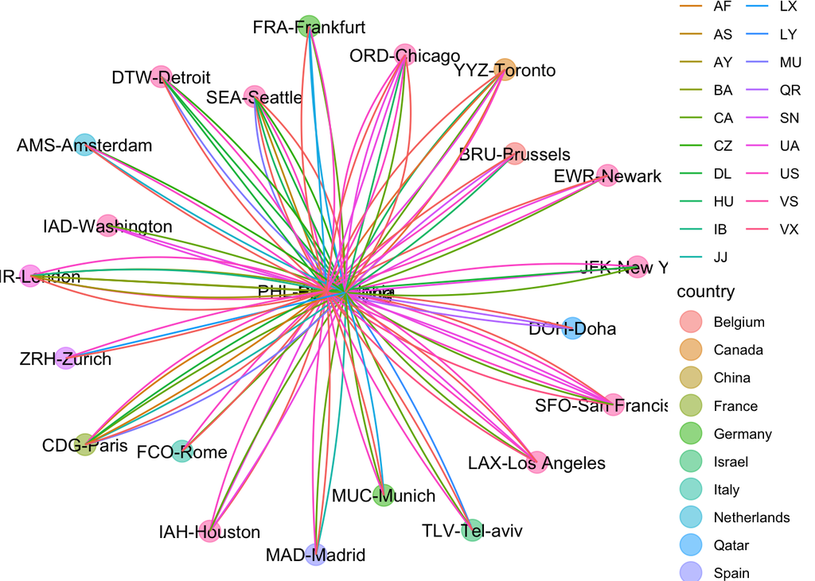

```r
# create phl2pek graph using shortest_path_airlines
phl2pek_edges = do.call("bind_rows",shortest_path_airlines) %>% tbl_df
phl2pek_vertices = left_join(
        bind_rows(
                phl2pek_edges %>% select(airport=from),
                phl2pek_edges %>% select(airport=to)
        ) %>% distinct(),
        routes_airports
)  %>%  dplyr::rename(name=airport, fullname=name) %>%
select(name, fullname, country, city, latitude, longitude, timezone)

phl2pek_g = igraph::graph_from_data_frame(
        phl2pek_edges,
        directed = T,
        phl2pek_vertices
)

# plot
ggraph(phl2pek_g, "kk") +
geom_node_point(aes(color=country), alpha=0.5, size=6) +
  geom_node_text(aes(label=paste(name, city, sep="-"))) +
  geom_edge_fan(aes(edge_colour=airline)) +
  theme_void()
```

# Exercise 3 (optional)

To limit our options, just choose the paths in which connecting airlines are from the same airline and plot like Exercise 2

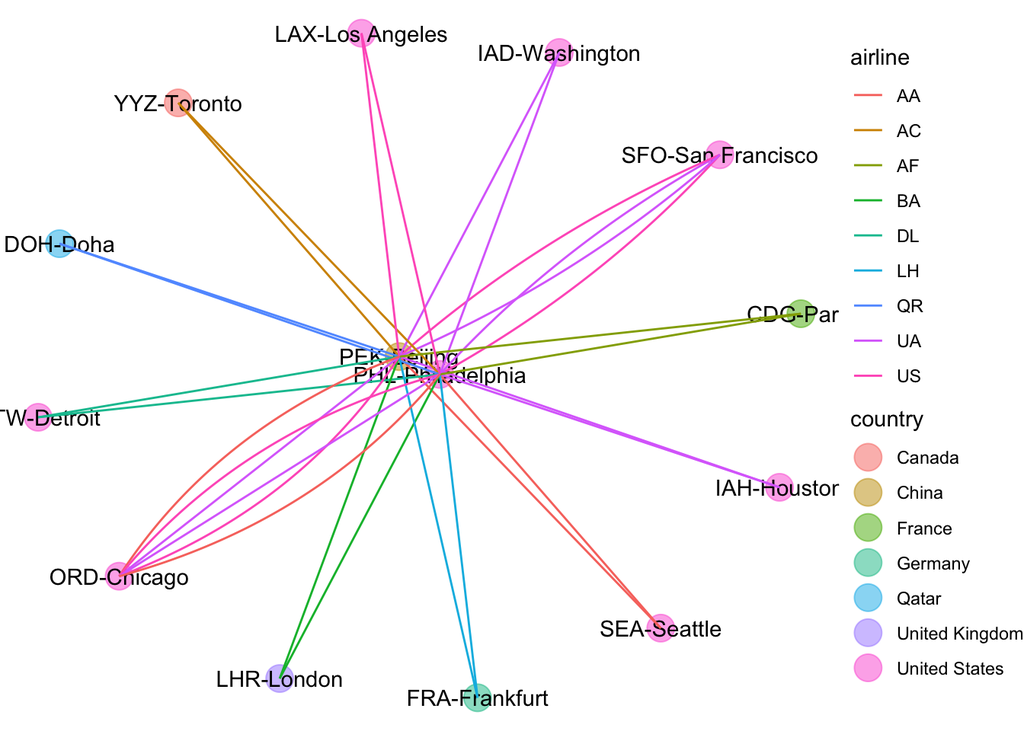

```r
# subset path with same airline to connect
subset_same_airline <- function(short_path_df) {
        airport2airport = short_path_df %>% distinct(from,to)
        path_airlines = lapply(
                1:nrow(airport2airport),
                function(x){
                        semi_join(short_path_df, airport2airport[x,]) %>%
                                pull(airline)
                        }
                )
        path_airlines = do.call("expand.grid", list(path_airlines,  stringsAsFactors = F))
        path_airlines = path_airlines[sapply(1:nrow(path_airlines), function(x){length(unique(unlist(path_airlines[x,]))) == 1}),]$Var1
        short_path_df %>% filter(airline %in% path_airlines)
}

shortest_path_same_airlines = lapply(shortest_path_airlines, subset_same_airline)

# create phl2pek graph using shortest_path_same_airlines
phl2pek_edges = do.call("bind_rows",shortest_path_same_airlines) %>% tbl_df

phl2pek_vertices = left_join(
        bind_rows(
                phl2pek_edges %>% select(airport=from),
                phl2pek_edges %>% select(airport=to)
        ) %>% distinct(),
        routes_airports
)  %>%  dplyr::rename(name=airport, fullname=name) %>%
select(name, fullname, country, city, latitude, longitude, timezone)

phl2pek_g = igraph::graph_from_data_frame(
        phl2pek_edges,
        directed = T,
        phl2pek_vertices
)

# plot
ggraph(phl2pek_g, "kk") +
geom_node_point(aes(color=country), alpha=0.5, size=6) +
  geom_node_text(aes(label=paste(name, city, sep="-"))) +
  geom_edge_fan(aes(edge_colour=airline)) +
  theme_void()
```